# Stepping Stones (potential structure, take 2)

2023-02-16

## Special Education Services

### Measure

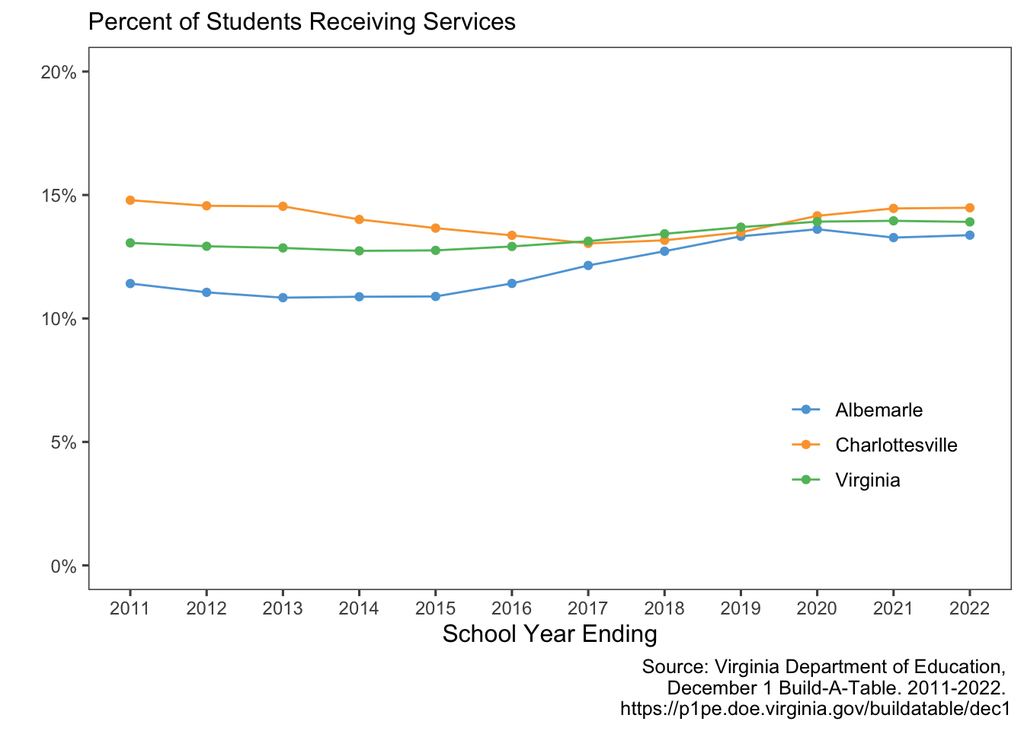

### About

The Individuals with Disability Education Act (IDEA) guarantees a free appropriate public education to all eligible children with disabilities. Students with a disability – hearing impairment, including deafness; speech or language impairment; visual impairment, including blindness; orthopedic impairment; autism; traumatic brain injury; developmental delay; other health impairment; intellectual disability; specific learning disability; serious emotional disturbance; or multiple disabilities – receive special education and related services under the IDEA. See [VDOE](https://www.doe.virginia.gov/programs-services/special-education) for more detail.

- *Why is this important?* Special education services are intended to insure students with disabilities have access to a meaningful public education.
- *Further Considerations:* Increasing numbers and percents of students receiving special education services could reflect increased access to needed resources, as disability diagnoses become less stigmatized in public understanding. However, research has highlighted that students of color may be disproportionately assigned a disability classification (e.g., [*Why are So Many Students of Color in Special Education?*](https://eric.ed.gov/?id=ED622195)) in a proces that continues to segregate children, affording fewer opportunities to children of color. We should take care in interpreting changes in this measure as clearly positive or negative outcomes.
- *Trend:* In Albemarle schools, the percent of students receiving special education services increased from 11.4% in 2010-2011 to 13.4% in 2021-2022; the percent has been fairly constant in Charlottesville schools, at 14.8% in 2010-2011 and 14.4% in 2021-2022. Statewide, the number has increased as well, from 13.1% in 2010-2011 to 13.9% in 2021-2022. This modest increase mirrors the trend nationally. From 2009–10 through 2020–21, the number of students ages 3–21 who received special education services under IDEA increased from 13% of total public school enrollment to 15% of total public school enrollment ([NCES](https://nces.ed.gov/programs/coe/indicator/cgg/students-with-disabilities#fn1)).
- *How do we measure this?* The percent of students is count of students identified as eligible for special education services over the count of all students in the school division.
- *Data source:* Virginia Department of Education, “December 1 Build-A-Table.” 2011-2022. https://p1pe.doe.virginia.gov/buildatable/dec1.
- *Files on Github:* https://github.com/virginiaequitycenter/stepping-stones/blob/main/code/sped_services.R